# Human Activity Execution Prediction

Ricardo Costa

5/18/2020

## Summary

In this project I will use data from accelerometers on the belt, forearm, arm, and dumbell of 6 participants. They were asked to perform barbell lifts correctly and incorrectly in 5 different ways. The goal of this project is to predict the manner in which users did the exercise.

## Exploring Data

The dataset is composed of 19,622 observations with 160 variables, being 159 of possible predictors and one final classifier (classe). You can see a histogram of the data bellow. There are five classes, with a sligth bigger concentration of observations of classe “A”.

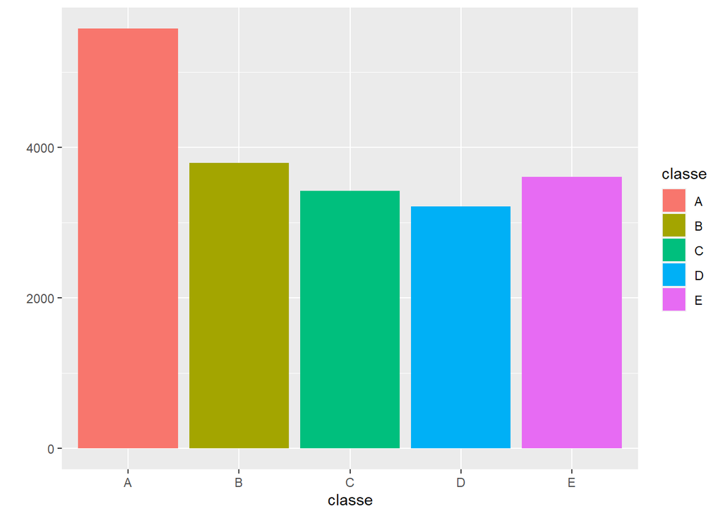

## Cleaning Data

Due to the number of possible predictors, I opted to drop columns with a large number of NAs, which were mainly aggregator (min, avg, stddev, var, skewness, amplitude, and kurtosis) of the other predictors.

Next steping was removing the predictors with a high correlation (over .90), keeping only one predictor for each correlated set.

## Data Partitioning

After cleaning data, the training data set had a total of 45 predictors plus the classificator (classe). To do a cross-validation test I partioned the data in training (3/4) and testing (1/4) datasets.

## Model Selection

I opted to build 4 models, all of them with the same `trainControl` (method = “cv”, number=5). Unfortunately the machine used to do the training is really old, so any number bigger than 5 would took too long to finish processing.

The chosen models where:

1. Random Forest
2. Boosting
3. Linear Discriminant Analysis
4. Decision Tree

As expected, Random Forest (Accuracy: 0.9946982) and Boosting (Accuracy: 0.9581974) got better results than LDA (Accuracy: 0.6790375). But the really unexpected results were the Decision Tree model, which got an accuracy of only 0.4949021.

After validating the Random Forest model using the testing data set, I got the confusion matrix bellow.

```
##           Reference
## Prediction    A    B    C    D    E
##          A 1394    6    0    0    0
##          B    1  937    2    0    0
##          C    0    6  852    5    1
##          D    0    0    1  798    3
##          E    0    0    0    1  897
```

After validating the Boosting model using the testing data set, I got the confusion matrix bellow.

```
##           Reference
## Prediction    A    B    C    D    E
##          A 1377   36    0    0    2
##          B   14  886   33    1   17
##          C    3   23  812   29   11
##          D    1    4   10  767   14
##          E    0    0    0    7  857
```

## Stacked Model

To finalize, I opted to build a stacked model combining both, boosting and random forest models. Using the stacked model I got the confusion matrix bellow, with an Accuracy of 0.9949021. Observing the confusion matrix, it is possible to identify that just one more observation was correctly classified using the stacked classifier than using the random forest classifier.

```
##           Reference
## Prediction    A    B    C    D    E
##          A 1394    6    0    0    0
##          B    1  937    2    0    0
##          C    0    6  852    5    0
##          D    0    0    1  798    3
##          E    0    0    0    1  898
```

## Expected out-of-sample error

The expected out-of-sample error corresponds to the inverse of accuracy (1-accuracy) in the testing data. In the two best models (stackd model and random forest), the expected out-of-sample error are 0.0050979 and 0.0053018, respectively.